# The DeepBlue epigenomic data server - R package

Felipe Albrecht

2016-04-21

# Introduction

The DeepBlue Epigenomic Data Server is a tool that allows researchers to access data from various epigenomic mapping consortia such as DEEP, BLUEPRINT or ROADMAP. DeepBlue can be accessed through a [web interface](http://deepblue.mpi-inf.mpg.de) or programmatically via its [API](http://deepblue.mpi-inf.mpg.de/api.php). The usage of the API is documented with [examples](http://deepblue.mpi-inf.mpg.de/examples.php), [use cases](http://deepblue.mpi-inf.mpg.de/use_cases.php), and a [user manual](http://deepblue.mpi-inf.mpg.de/manual). While the description of the API is language agnostic, the examples and use cases shown online are focused on the python language. However, the R package presented here also enables access to the DeepBlue API directly within the R statistical environment and provides convenient functionality for triggering operations on the DeepBlue server as well as for data retrievel using R functions. In the following, we give a brief introduction to the package and subsequently show how python examples from the online documentation can be reproduced with it.

## What is DeepBlue ?

A wealth of epigenomic data has been collected over the past decade by large epigenomic mapping consortia. Event though most of these data are publicly available, the task of identifiying, downloading and processing data from various experiments is challenging. Recognizing that these tedious steps need to be tackled programmatically, we developed the DeepBlue epigenomic data server. Epigenome data from the different epigenome mapping consortia are accessible with standardized metadata. An experiment is the most important entity in DeepBlue and typically encompasses a single file (usually a bed or wig file) with a set of mandatory metadata: name, genome assembly, epigenetic mark, biosource, sample, technique, and project. For the sake of organization, all metadata fields are part of controlled vocabularies, some of which are imported from ontologies (CL, EFO, and UBERON, to name a few). DeepBlue also contains annotations, i.e. auxiliary data that is helpful in epigenomic analysis, such as, for example, CpG Islands, promoter regions, and genes. DeepBlue provides different types of commands, such as listing and searching commands as well as commands for data retrieval. A typical work-flow for the latter is to select, filter, transform, and finally download the selected data. For a more thorough description of DeepBlue you may find additional material in [DeepBlue’s NAR web server issue publication](http://nar.oxfordjournals.org/content/early/2016/04/15/nar.gkw211.full). If you find DeepBlue useful and use it in your project consider citing this paper.

Important note: With the exception of data aggregation tasks, DeepBlue does not alter the imported data, i.e. it remains exactly as provided by the epigenome mapping consortia.

# Getting started

## Installation

Automatic installation of DeepBlue-R and its companion packages can be performed using the devtools package. All you have to do is to execute the following command in your R environment:

```r
devtools::install_github("MPIIComputationalEpigenetics/DeepBlue-R", build_vignettes=TRUE)
```

You can test your installation by saying hello to the DeepBlue server:

```r
deepblue.info("me")
```

## Overview of DeepBlue commands

DeepBlue provides a comprehensive programmatic interface for finding, selecting, filtering, summarizing and downloading annotated genomic region sets. Downloaded region sets are stored using the GenomicRanges R package, which allows for downloaded region sets to be further processed, visualized and analyzed with existing R packages such as LOLA or GViz.

A list of all commands available by DeepBlue is provided in its [API page](http://deepblue.mpi-inf.mpg.de/api.php).

For reference, following are listed the most used DeepBlue commands:

| Category | Command | Description |
| --- | --- | --- |
| Information | info | Obtain information about an entity |
| List and search | list genomes | List all registered genomes |
|  | list biosources | List all registered biosources |
|  | list samples | List all registered samples |
|  | list epigenetic marks | List all registered epigenetic marks |
|  | list experiments | List all available experiments |
|  | list annotations | List all available annotations |
|  | search | Perform a full-text search |
| Selection | select regions | Select regions from experiments |
|  | select experiments | Select regions from experiments |
|  | select annotations | Select regions from annotations |
|  | select genes | Select genes as regions |
|  | tiling regions | Generate tiling regions |
|  | input regions | Upload and use a small region-set |
| Operation | aggregate | Aggregate and summarize regions |
|  | filter regions | Filter regions using their attributes |
|  | flank | Generate flanking regions |
|  | intersection | Filter overlapping regions |
|  | merge queries | Merge two regions set |
| Result | count regions | Count selected regions |
|  | score matrix | Request a score matrix |
|  | get regions | Request the selected regions |
| Request | get request data | Obtain the requested data |

This package provides a set of functions for facilitate the API usage:

| Category | Command | Description |
| --- | --- | --- |
| Request | batch_export_results | Download the data a set of requests |
|  | download_request_data | Download and convert the requested data |

# DeepBlue usage examples

In the following we give a number of increasingly complex examples illustrating what DeepBlue can achieve for you in your epigenomic data analysis work-flow. We go beyond the online description of these examples by showing how the retrieved information can be further used in R.

One of the first tasks in DeepBlue is listing the data. This can be achieved in three ways:

- Using full-text search with the `search` command
- Listing the available data with the `list_*` commands
- Using the companion [DeepBlue web interface](http://deepblue.mpi-inf.mpg.de/) site for listing the data

### Full-text search

In this example, we use the command `search` to find experiments that contain the texts H3k27AC, blood, and peaks in their metadata. We put the names in single quotes to show that these names must be in the metadata.

```r
# We are selecting the experiments with terms 'H3k27AC', 'blood', and 'peak' in the metadata.
experiments_found = deepblue.search(keyword="'H3k27AC' 'blood' 'peak'", type="experiments")

custom_table = do.call("rbind", lapply(experiments_found, function(experiment){
  experiment_id = experiment[[1]]
  # Obtain the information about the experiment_id
  info = deepblue.info(experiment_id)
  experiment_info = info[[1]]
  # Print the experiment name, project, biosource, and epigenetic mark.
  with(experiment_info, { data.frame(name = name, project = project, biosource = sample_info$biosource_name, epigenetic_mark = epigenetic_mark) })
}))
  head(custom_table)
```

```
##                          name             project biosource
## 1 E038-H3K27ac.narrowPeak.bed Roadmap Epigenomics     BLOOD
## 2 E047-H3K27ac.narrowPeak.bed Roadmap Epigenomics     BLOOD
## 3 E048-H3K27ac.narrowPeak.bed Roadmap Epigenomics     BLOOD
## 4 E037-H3K27ac.narrowPeak.bed Roadmap Epigenomics     BLOOD
## 5 E045-H3K27ac.narrowPeak.bed Roadmap Epigenomics     BLOOD
## 6 E040-H3K27ac.narrowPeak.bed Roadmap Epigenomics     BLOOD
##   epigenetic_mark
## 1         H3K27ac
## 2         H3K27ac
## 3         H3K27ac
## 4         H3K27ac
## 5         H3K27ac
## 6         H3K27ac
```

### Listing experiments

We use the `list_experiments` command to list all experiments with the corresponding values in theirs metadata.

```r
experiments = deepblue.list_experiments(type="peaks", epigenetic_mark="H3K4me3", biosource=c("inflammatory macrophage", "macrophage"), project="BLUEPRINT Epigenome")
do.call("rbind", lapply(experiments, function(x){ data.frame(id = x[[1]], experiment_name = x[[2]])}))
```

```
##        id                                    experiment_name
## 1  e55141 S0022IH2.ERX300720.H3K4me3.bwa.GRCh38.20150527.bed
## 2  e55091 S00H6OH2.ERX604476.H3K4me3.bwa.GRCh38.20150527.bed
## 3  e55005 S001S7H2.ERX300682.H3K4me3.bwa.GRCh38.20150527.bed
## 4  e54994 S001MJH1.ERX300707.H3K4me3.bwa.GRCh38.20150527.bed
## 5  e54868 S0018AH2.ERX240840.H3K4me3.bwa.GRCh38.20150527.bed
## 6  e54787 S007SKH1.ERX406972.H3K4me3.bwa.GRCh38.20150527.bed
## 7  e55109 S001S7H1.ERX300725.H3K4me3.bwa.GRCh38.20150527.bed
## 8  e54980 C005VGH1.ERX240842.H3K4me3.bwa.GRCh38.20150527.bed
## 9  e55049 S0022IH1.ERX300718.H3K4me3.bwa.GRCh38.20150527.bed
## 10 e55048 S00NM5H1.ERX547243.H3K4me3.bwa.GRCh38.20150527.bed
## 11 e55038 S00390H1.ERX300683.H3K4me3.bwa.GRCh38.20150527.bed
## 12 e54993 S00NN3H1.ERX547246.H3K4me3.bwa.GRCh38.20150527.bed
## 13 e54947 S00NK9H1.ERX547240.H3K4me3.bwa.GRCh38.20150527.bed
## 14 e54909 S00BXVH1.ERX547225.H3K4me3.bwa.GRCh38.20150527.bed
## 15 e54899 S00BYTH1.ERX547228.H3K4me3.bwa.GRCh38.20150527.bed
## 16 e54765 S00198H2.ERX300698.H3K4me3.bwa.GRCh38.20150527.bed
## 17 e54737 S00BHQH1.ERX406976.H3K4me3.bwa.GRCh38.20150527.bed
```

### Accessing the extra-metadata

The extra-metadata is important because it contains information that is not stored in the mandatory metadata fields. We use the info command to access an experiment’s metadata and its extra-metadata fields. The following example prints the `file_url` attribute that it is contained in the data imported from the ENCODE project.

```r
info = deepblue.info("e30000")
print(info[[1]]$extra_metadata$file_url)
```

```
## [1] "https://www.encodeproject.org/files/ENCFF001YBB/"
```

### Select epigenomic data

We use the `select_experiments` command to select all genomic regions from the two informed experiments. We use the `count_regions` command with the `query_id` value returned by the `select_experiments`. The `count_regions` command is asynchronous. It means that the user receives a `request_id` and should check the status of this request. The specific DeepBlue-R package command `download_request_data` wait for the processing finishes in the server, download the data, and convert to a GRanges object.

```r
query_id = deepblue.select_experiments(experiment_name=c("BL-2_c01.ERX297416.H3K27ac.bwa.GRCh38.20150527.bed", "S008SGH1.ERX406923.H3K27ac.bwa.GRCh38.20150728.bed"))
# Count how many regions where selected
request_id = deepblue.count_regions(query_id=query_id)
# Download the request data as soon as processing is finished
requested_data = deepblue.download_request_data(request_id=request_id)
print(paste("The selected experiments have", requested_data, "regions."))
```

```
## [1] "The selected experiments have 115347 regions."
```

### Output with desired columns

We use the `select_experiments` command to select the genomic regions from the experiments that are in the chromosome 1, position 0 to 50,000,000.

We use the `get_regions` command with the `query_id` value returned by the `select_experiments` and the desired file columns. The columns @NAME and @BIOSOURCE include the experiment name and the experiment biosource in the row output.

The `get_regions` command is asynchronous. It means that the user receives a `request_id` and should check the status of this request. The specific DeepBlue-R package command `download_request_data` wait for the processing finishes in the server, download the data, and convert to a GRanges object.

```r
query_id = deepblue.select_experiments (experiment_name = c("BL-2_c01.ERX297416.H3K27ac.bwa.GRCh38.20150527.bed", "S008SGH1.ERX406923.H3K27ac.bwa.GRCh38.20150728.bed"), chromosome="chr1", start=0, end=50000000)

# Retrieve the experiments data (The @NAME meta-column is used to include the experiment name and @BIOSOURCE for experiment's biosource
request_id = deepblue.get_regions(query_id=query_id, output_format="CHROMOSOME,START,END,SIGNAL_VALUE,PEAK,@NAME,@BIOSOURCE")
regions = deepblue.download_request_data(request_id=request_id)
regions
```

```
## GRanges object with 3782 ranges and 4 metadata columns:
##          seqnames               ranges strand   | SIGNAL_VALUE      PEAK
##             <Rle>            <IRanges>  <Rle>   |    <numeric> <integer>
##      [1]     chr1     [270668, 270987]      *   |       6.5758        39
##      [2]     chr1     [271277, 271468]      *   |       6.2148       136
##      [3]     chr1     [273768, 274209]      *   |      14.1567       164
##      [4]     chr1     [778377, 778676]      *   |       8.0198       154
##      [5]     chr1     [778409, 778678]      *   |       4.5767       123
##      ...      ...                  ...    ... ...          ...       ...
##   [3778]     chr1 [47437324, 47437604]      *   |       6.2148       110
##   [3779]     chr1 [47437420, 47437621]      *   |       3.7686       147
##   [3780]     chr1 [47437751, 47438038]      *   |       9.6553       149
##   [3781]     chr1 [48245368, 48245867]      *   |       4.7708       346
##   [3782]     chr1 [48542755, 48543280]      *   |       7.3002       152
##                                                       @NAME   @BIOSOURCE
##                                                 <character>  <character>
##      [1] S008SGH1.ERX406923.H3K27ac.bwa.GRCh38.20150728.bed myeloid cell
##      [2] S008SGH1.ERX406923.H3K27ac.bwa.GRCh38.20150728.bed myeloid cell
##      [3] S008SGH1.ERX406923.H3K27ac.bwa.GRCh38.20150728.bed myeloid cell
##      [4] S008SGH1.ERX406923.H3K27ac.bwa.GRCh38.20150728.bed myeloid cell
##      [5] BL-2_c01.ERX297416.H3K27ac.bwa.GRCh38.20150527.bed         BL-2
##      ...                                                ...          ...
##   [3778] S008SGH1.ERX406923.H3K27ac.bwa.GRCh38.20150728.bed myeloid cell
##   [3779] BL-2_c01.ERX297416.H3K27ac.bwa.GRCh38.20150527.bed         BL-2
##   [3780] S008SGH1.ERX406923.H3K27ac.bwa.GRCh38.20150728.bed myeloid cell
##   [3781] S008SGH1.ERX406923.H3K27ac.bwa.GRCh38.20150728.bed myeloid cell
##   [3782] S008SGH1.ERX406923.H3K27ac.bwa.GRCh38.20150728.bed myeloid cell
##   -------
##   seqinfo: 1 sequence from an unspecified genome; no seqlengths
```

### Filter epigenomic data by metadata

We use the `list_samples` command to obtain all samples from the biosource myeloid cell from the BLUEPRINT project. The `list_samples` returns a list of samples with their IDs and content.

We extract the IDs from this list and use it in the `select_regions` command.

The `select_regions` command selects the genomic regions that are in the chromosome 1, position 0 to 50,000 of all experiments that have the given samples IDs.

Then, we use the `get_regions` command with the parameters: `query_id` returned by the `select_regions` and the desired file columns. The columns @NAME, SAMPLE_ID, and @BIOSOURCE include the experiment name, the sample ID, and the experiment biosource in the row output.

The `get_regions` command is asynchronous. It means that the user receives a `request_id` and should check the status of this request. The specific DeepBlue-R package command `download_request_data` wait for the processing finishes in the server, download the data, and convert to a GRanges object.

```r
samples = deepblue.list_samples(biosource="myeloid cell", extra_metadata = list("source" = "BLUEPRINT Epigenome"))
samples_ids = deepblue.extract_ids(samples)
query_id = deepblue.select_regions(genome="GRCh38", sample=samples_ids, chromosome="chr1", start=0, end=50000)
request_id = deepblue.get_regions(query_id=query_id, output_format="CHROMOSOME,START,END,@NAME,@SAMPLE_ID,@BIOSOURCE")
regions = deepblue.download_request_data(request_id=request_id)
head(regions,1)
```

```
## GRanges object with 1 range and 3 metadata columns:
##       seqnames         ranges strand |
##          <Rle>      <IRanges>  <Rle> |
##   [1]     chr1 [10021, 10338]      * |
##                                                    @NAME  @SAMPLE_ID
##                                              <character> <character>
##   [1] S00Q7NH1.ERX712672.H3K27ac.bwa.GRCh38.20150527.bed       s8237
##         @BIOSOURCE
##        <character>
##   [1] myeloid cell
##   -------
##   seqinfo: 1 sequence from an unspecified genome; no seqlengths
```

### Filter epigenomic data by region attributes

We use the `select_experiments` command for selecting the genomic regions from the experiments that are in the chromosome 1, position 0 to 50,000,000.

We filter the genomic regions that have the value of the column SIGNAL_VALUE higher than 10.

We filter the genomic regions that have the value of the column PEAK higher than 1000.

Then, we use the `get_regions` command with the parameters: `query_id` returned by the select_experiments and the desired file columns. The columns @NAME and @BIOSOURCE include the experiment name and the experiment biosource in the row output.

The `get_regions` command is asynchronous. It means that the user receives a `request_id` and should check the status of this request. The specific DeepBlue-R package command `download_request_data` wait for the processing finishes in the server, download the data, and convert to a GRanges object.

```r
query_id = deepblue.select_experiments(experiment_name = c("BL-2_c01.ERX297416.H3K27ac.bwa.GRCh38.20150527.bed", "S008SGH1.ERX406923.H3K27ac.bwa.GRCh38.20150728.bed"), chromosome="chr1", start=0, end=50000000)
query_id_filter_signal = deepblue.filter_regions (query_id=query_id, field="SIGNAL_VALUE", operation=">", value="10", type="number")
query_id_filters = deepblue.filter_regions (query_id=query_id_filter_signal, field="PEAK", operation=">", value="1000", type="number")
request_id = deepblue.get_regions(query_id=query_id_filters, output_format="CHROMOSOME,START,END,SIGNAL_VALUE,PEAK,@NAME,@BIOSOURCE")
regions = deepblue.download_request_data(request_id=request_id)
regions
```

```
## GRanges object with 160 ranges and 4 metadata columns:
##         seqnames               ranges strand   | SIGNAL_VALUE      PEAK
##            <Rle>            <IRanges>  <Rle>   |    <numeric> <integer>
##     [1]     chr1   [1142428, 1144001]      *   |      10.9313      1275
##     [2]     chr1   [1573400, 1575582]      *   |      17.8805      1094
##     [3]     chr1   [1612814, 1616174]      *   |      32.2064      2802
##     [4]     chr1   [1668761, 1670450]      *   |      20.2936      1017
##     [5]     chr1   [1778583, 1783797]      *   |      35.4277      1293
##     ...      ...                  ...    ... ...          ...       ...
##   [156]     chr1 [44729979, 44731486]      *   |      15.1388      1262
##   [157]     chr1 [44774644, 44776655]      *   |      16.3227      1160
##   [158]     chr1 [44806139, 44811000]      *   |      22.8156      1381
##   [159]     chr1 [46301112, 46304262]      *   |      19.8041      2397
##   [160]     chr1 [46579227, 46582046]      *   |      15.9613      1824
##                                                      @NAME   @BIOSOURCE
##                                                <character>  <character>
##     [1] BL-2_c01.ERX297416.H3K27ac.bwa.GRCh38.20150527.bed         BL-2
##     [2] S008SGH1.ERX406923.H3K27ac.bwa.GRCh38.20150728.bed myeloid cell
##     [3] S008SGH1.ERX406923.H3K27ac.bwa.GRCh38.20150728.bed myeloid cell
##     [4] S008SGH1.ERX406923.H3K27ac.bwa.GRCh38.20150728.bed myeloid cell
##     [5] S008SGH1.ERX406923.H3K27ac.bwa.GRCh38.20150728.bed myeloid cell
##     ...                                                ...          ...
##   [156] S008SGH1.ERX406923.H3K27ac.bwa.GRCh38.20150728.bed myeloid cell
##   [157] S008SGH1.ERX406923.H3K27ac.bwa.GRCh38.20150728.bed myeloid cell
##   [158] S008SGH1.ERX406923.H3K27ac.bwa.GRCh38.20150728.bed myeloid cell
##   [159] S008SGH1.ERX406923.H3K27ac.bwa.GRCh38.20150728.bed myeloid cell
##   [160] S008SGH1.ERX406923.H3K27ac.bwa.GRCh38.20150728.bed myeloid cell
##   -------
##   seqinfo: 1 sequence from an unspecified genome; no seqlengths
```

### Find overlapping regions

We use the `select_experiments` command to select the genomic regions from the experiments that are in the chromosome 1, position 0 to 50,000,000.

We use the `select_annotations` command to select the genomic regions in the chromosome 1 of the annotation promoters of the genome assembly GRCh38.

The command intersection filters all regions of the `query_id` that overlap with at least one `promoters_id` region.

We use the `get_regions` command with the parameters: `query_id` returned by the `select_experiments` and the desired file columns. The columns @NAME and @BIOSOURCE include the experiment name and the experiment biosource in the row output.

The `get_regions` command is asynchronous. It means that the user receives a `request_id` and should check the status of this request. The specific DeepBlue-R package command `download_request_data` wait for the processing finishes in the server, download the data, and convert to a GRanges object.

```r
query_id = deepblue.select_experiments(experiment_name = c("BL-2_c01.ERX297416.H3K27ac.bwa.GRCh38.20150527.bed", "S008SGH1.ERX406923.H3K27ac.bwa.GRCh38.20150728.bed"), chromosome="chr1", start=0, end=50000000)
promoters_id = deepblue.select_annotations(annotation_name="promoters", genome="GRCh38", chromosome="chr1")
intersect_id = deepblue.intersection(query_a_id=query_id, query_b_id=promoters_id)
request_id = deepblue.get_regions(query_id=intersect_id, output_format="CHROMOSOME,START,END,SIGNAL_VALUE,PEAK,@NAME,@BIOSOURCE")
regions = deepblue.download_request_data(request_id=request_id)
regions
```

```
## GRanges object with 608 ranges and 4 metadata columns:
##         seqnames               ranges strand   | SIGNAL_VALUE      PEAK
##            <Rle>            <IRanges>  <Rle>   |    <numeric> <integer>
##     [1]     chr1     [903997, 904177]      *   |       4.7708        89
##     [2]     chr1     [904302, 905111]      *   |       5.4928       560
##     [3]     chr1     [910269, 910975]      *   |       4.7201       136
##     [4]     chr1     [911973, 913915]      *   |      17.0446       624
##     [5]     chr1     [923976, 924329]      *   |       4.7201       109
##     ...      ...                  ...    ... ...          ...       ...
##   [604]     chr1 [46667452, 46667747]      *   |       3.4355       116
##   [605]     chr1 [46718435, 46719027]      *   |       6.2499       230
##   [606]     chr1 [47313340, 47313980]      *   |       6.8711       174
##   [607]     chr1 [47313412, 47313588]      *   |       4.8558       120
##   [608]     chr1 [47313632, 47314141]      *   |      10.2801       371
##                                                      @NAME   @BIOSOURCE
##                                                <character>  <character>
##     [1] S008SGH1.ERX406923.H3K27ac.bwa.GRCh38.20150728.bed myeloid cell
##     [2] S008SGH1.ERX406923.H3K27ac.bwa.GRCh38.20150728.bed myeloid cell
##     [3] S008SGH1.ERX406923.H3K27ac.bwa.GRCh38.20150728.bed myeloid cell
##     [4] S008SGH1.ERX406923.H3K27ac.bwa.GRCh38.20150728.bed myeloid cell
##     [5] S008SGH1.ERX406923.H3K27ac.bwa.GRCh38.20150728.bed myeloid cell
##     ...                                                ...          ...
##   [604] BL-2_c01.ERX297416.H3K27ac.bwa.GRCh38.20150527.bed         BL-2
##   [605] BL-2_c01.ERX297416.H3K27ac.bwa.GRCh38.20150527.bed         BL-2
##   [606] BL-2_c01.ERX297416.H3K27ac.bwa.GRCh38.20150527.bed         BL-2
##   [607] S008SGH1.ERX406923.H3K27ac.bwa.GRCh38.20150728.bed myeloid cell
##   [608] S008SGH1.ERX406923.H3K27ac.bwa.GRCh38.20150728.bed myeloid cell
##   -------
##   seqinfo: 1 sequence from an unspecified genome; no seqlengths
```

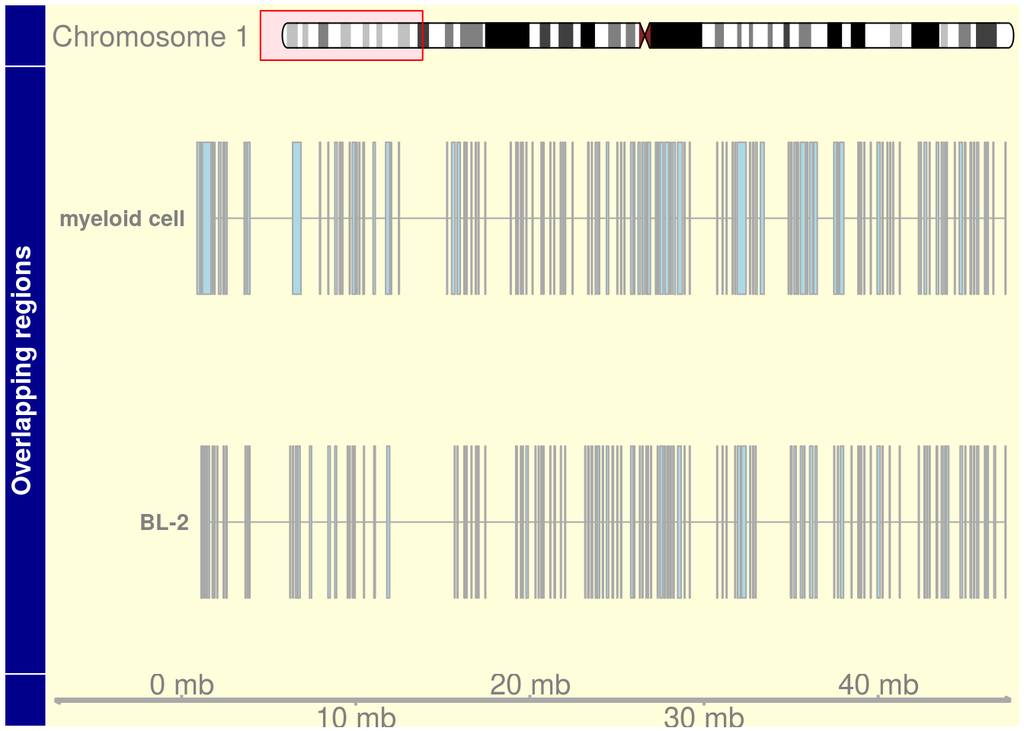

```r
library(Gviz)
atrack <- AnnotationTrack(regions, name = "Overlapping regions", group = regions$`@BIOSOURCE`, genome="hg38")
gtrack <- GenomeAxisTrack()
itrack <- IdeogramTrack(genome = "hg38", chromosome = "chr1")
plotTracks(list(itrack, atrack, gtrack), groupAnnotation="group", fontsize=18,
           background.panel = "#FFFEDB", background.title = "darkblue")
```

### Retrieve DNA sequences

We use the `select_experiments` command to select the genomic regions from the experiments that are in the chromosome 1, position 0 to 50,000,000.

We filter the genomic regions that have the value of the column SIGNAL_VALUE higher than 10.

We filter the genomic regions that have the value of the column PEAK higher than 1000.

The meta-column @LENGTH contains the genomic region length, and we filter the genomic regions where this value is smaller than 2,000.

We use the `get_regions` with the `query_id` returned by the `select_experiments` and the desired file columns. In this case, we use the meta-column @SEQUENCE, that includes the DNA Sequence in the genomic region output.

The `get_regions` command is asynchronous. It means that the user receives a `request_id` and should check the status of this request. The specific DeepBlue-R package command `download_request_data` wait for the processing finishes in the server, download the data, and convert to a GRanges object.

```r
query_id = deepblue.select_experiments(experiment_name = c("BL-2_c01.ERX297416.H3K27ac.bwa.GRCh38.20150527.bed", "S008SGH1.ERX406923.H3K27ac.bwa.GRCh38.20150728.bed"), chromosome="chr1", start=0, end=50000000)
query_id_filter_signal = deepblue.filter_regions (query_id=query_id, field="SIGNAL_VALUE", operation=">", value="10", type="number")
query_id_filters = deepblue.filter_regions (query_id=query_id_filter_signal, field="PEAK", operation=">", value="1000", type="number")
query_id_filter_length = deepblue.filter_regions (query_id=query_id_filters, field="@LENGTH", operation="<", value="2000", type="number")
request_id = deepblue.get_regions(query_id=query_id_filter_length, output_format="CHROMOSOME,START,END,SIGNAL_VALUE,PEAK,@NAME,@BIOSOURCE,@LENGTH,@SEQUENCE")
regions = deepblue.download_request_data(request_id=request_id)
head(regions, 1)
```

```
## GRanges object with 1 range and 6 metadata columns:
##       seqnames             ranges strand | SIGNAL_VALUE      PEAK
##          <Rle>          <IRanges>  <Rle> |    <numeric> <integer>
##   [1]     chr1 [1142428, 1144001]      * |      10.9313      1275
##                                                    @NAME  @BIOSOURCE
##                                              <character> <character>
##   [1] BL-2_c01.ERX297416.H3K27ac.bwa.GRCh38.20150527.bed        BL-2
##           @LENGTH
##       <character>
##   [1]        1573
##                                                                                                                                                                                                                                                                                                          …
##                                                                                                                                                                                                                                                                                                          …
##   [1] CCAGGCTGGTCTCAAACTCCTGACCTCAAATGATCCGCCCACCTCGGCCTCCCACAGTGC…
##   -------
##   seqinfo: 1 sequence from an unspecified genome; no seqlengths
```

### DNA pattern matching operations

We use the `find_pattern` command to generate an annotation of the genomic locations where the pattern TATAA happens in the genome assembly GRCh38.

The `find_pattern` command requires permission to include annotations. If the user (e.g. anonymous user) does not have this permission, an error will be returned.

Nevertheless, we have already processed this pattern, and the annotation was generated with the name “Pattern TATAAA (non-overlap) in the genome GRCh38”. We selected the genomic regions of the first chromosome of this annotation with the select_annotations command.

We use the `select_experiments` command to select the genomic regions from the experiments that are in the chromosome 1, position 0 to 50,000,000.

The command `intersection` selects all regions of the `query_id` that overlap with at least one tataa_regions region.

We use the `get_regions` with the `query_id` returned by the `select_experiments` and the desired file columns. In this case, we use the meta-column @SEQUENCE, that includes the DNA Sequence in the genomic region output.

The `get_regions` command is asynchronous. It means that the user receives a `request_id` and should check the status of this request. The specific DeepBlue-R package command `download_request_data` wait for the processing finishes in the server, download the data, and convert to a GRanges object.

```r
tataa_regions = deepblue.select_annotations(annotation_name="Pattern TATAAA (non-overlap) in the genome GRCh38", genome="GRCh38", chromosome="chr1")
query_id = deepblue.select_experiments (experiment_name= c("BL-2_c01.ERX297416.H3K27ac.bwa.GRCh38.20150527.bed", "S008SGH1.ERX406923.H3K27ac.bwa.GRCh38.20150728.bed"), chromosome="chr1", start=0, end=50000000)
overlapped = deepblue.intersection(query_a_id=query_id, query_b_id=tataa_regions)
request_id=deepblue.get_regions(overlapped, "CHROMOSOME,START,END,SIGNAL_VALUE,PEAK,@NAME,@BIOSOURCE,@LENGTH,@SEQUENCE")
regions = deepblue.download_request_data(request_id=request_id)
head(regions, 5)
```

```
## GRanges object with 5 ranges and 6 metadata columns:
##       seqnames             ranges strand | SIGNAL_VALUE      PEAK
##          <Rle>          <IRanges>  <Rle> |    <numeric> <integer>
##   [1]     chr1 [ 273768,  274209]      * |      14.1567       164
##   [2]     chr1 [ 911203,  911477]      * |       4.8558       105
##   [3]     chr1 [ 916813,  917682]      * |      10.5467       183
##   [4]     chr1 [1231079, 1231868]      * |       7.1834       310
##   [5]     chr1 [1398379, 1398826]      * |       4.3725       345
##                                                    @NAME   @BIOSOURCE
##                                              <character>  <character>
##   [1] S008SGH1.ERX406923.H3K27ac.bwa.GRCh38.20150728.bed myeloid cell
##   [2] S008SGH1.ERX406923.H3K27ac.bwa.GRCh38.20150728.bed myeloid cell
##   [3] S008SGH1.ERX406923.H3K27ac.bwa.GRCh38.20150728.bed myeloid cell
##   [4] BL-2_c01.ERX297416.H3K27ac.bwa.GRCh38.20150527.bed         BL-2
##   [5] BL-2_c01.ERX297416.H3K27ac.bwa.GRCh38.20150527.bed         BL-2
##           @LENGTH
##       <character>
##   [1]         441
##   [2]         274
##   [3]         869
##   [4]         789
##   [5]         447
##                                                                                                                                                                                                                                                                                                          …
##                                                                                                                                                                                                                                                                                                          …
##   [1]                                                                                                                                                                                                                                                                                                    …
##   [2]                                                                                                                                                                                                                                                                                                    …
##   [3]                                                                                                   TTTATTGCACAAATTATTAACGACCAGAGAATGAATGACTCTGTAATCAGATCAGGTTGC…
##   [4] AAGACCCTGTCTCGAAAAAGGGGGAATAAAAAGTAACCCAAAAGTAACTATAAATATCAG…
##   [5]                                                                                                                                                                                                                                                                                                    …
##   -------
##   seqinfo: 1 sequence from an unspecified genome; no seqlengths
```

### Genes

We use the `select_genes` command to select the gene RP11-34P13 from the gene set gencode v23.

The selected genes behave like a regular genomic region that, for example, can be filtered by their content.

We use the @GENE_ATTRIBUTE meta-column to select the genomic regions that are lincRNA.

We use the `get_regions` with the `query_id` returned by the `select_experiments` and the desired file columns.

The `get_regions` command is asynchronous. It means that the user receives a `request_id` and should check the status of this request. The specific DeepBlue-R package command `download_request_data` wait for the processing finishes in the server, download the data, and convert to a GRanges object.

```r
q_genes = deepblue.select_genes(genes_name="RP11-34P13", gene_set="gencode v23")
q_filter = deepblue.filter_regions(query_id=q_genes, field="@GENE_ATTRIBUTE(gene_type)", operation="==", value="lincRNA", type="string")
request_id=deepblue.get_regions(q_filter, "CHROMOSOME,START,END,GTF_ATTRIBUTES")
regions = deepblue.download_request_data(request_id=request_id)
```

### Aggregate and summarize regions

We use the `get_regions` command with the `query_id` value returned by the select_experiments and the desired file columns.

We use the `select_annotations` command to select the genomic regions, from position 0 to 50,000,000 in the chromosome 1 of the annotation CpG Islands of the genome assembly GRCh38.

The command `aggregate` aggregates the `query_id` regions using the `cpg_islands` regions as boundaries.

The aggregate values can be accessed through the @AGG meta-columns.

```r
query_id = deepblue.select_experiments (experiment=c("GC_T14_10.CPG_methylation_calls.bs_call.GRCh38.20150707.wig"), chromosome="chr1", start=0, end=50000000)
cpg_islands = deepblue.select_annotations(annotation_name="CpG Islands", genome="GRCh38", chromosome="chr1", start=0, end=50000000)
# Aggregate
overlapped = deepblue.aggregate (data_id=query_id, ranges_id=cpg_islands, column="VALUE" )

# Retrieve the experiments data (The @NAME meta-column is used to include the experiment name and @BIOSOURCE for experiment's biosource
request_id = deepblue.get_regions(query_id=overlapped, output_format="CHROMOSOME,START,END,@AGG.MIN,@AGG.MAX,@AGG.MEDIAN,@AGG.MEAN,@AGG.VAR,@AGG.SD,@AGG.COUNT")
regions = deepblue.download_request_data(request_id=request_id)
regions
```

```
## GRanges object with 1100 ranges and 7 metadata columns:
##          seqnames               ranges strand   |    @AGG.MIN    @AGG.MAX
##             <Rle>            <IRanges>  <Rle>   | <character> <character>
##      [1]     chr1     [ 28735,  29737]      *   |      0.0000      0.0290
##      [2]     chr1     [135124, 135563]      *   |      0.7000      1.0000
##      [3]     chr1     [199251, 200121]      *   |      0.0000      0.0000
##      [4]     chr1     [368792, 370063]      *   |      1.0000      1.0000
##      [5]     chr1     [381172, 382185]      *   |      0.8000      1.0000
##      ...      ...                  ...    ... ...         ...         ...
##   [1096]     chr1 [47984198, 47984472]      *   |      0.0000      0.1450
##   [1097]     chr1 [47994140, 47994389]      *   |      0.4780      0.9880
##   [1098]     chr1 [47996459, 47997929]      *   |      0.0000      0.2610
##   [1099]     chr1 [48471632, 48472399]      *   |      0.0000      0.1180
##   [1100]     chr1 [48776519, 48777138]      *   |      0.0000      0.0370
##          @AGG.MEDIAN   @AGG.MEAN    @AGG.VAR     @AGG.SD  @AGG.COUNT
##          <character> <character> <character> <character> <character>
##      [1]      0.0000      0.0005      0.0000      0.0036          64
##      [2]      0.9660      0.9363      0.0062      0.0785          30
##      [3]      0.0000      0.0000      0.0000      0.0000          27
##      [4]      1.0000      1.0000      0.0000      0.0000           2
##      [5]      1.0000      0.9575      0.0056      0.0745          12
##      ...         ...         ...         ...         ...         ...
##   [1096]      0.0380      0.0494      0.0014      0.0378          36
##   [1097]      0.9540      0.9264      0.0120      0.1095          19
##   [1098]      0.0000      0.0190      0.0014      0.0379         145
##   [1099]      0.0000      0.0143      0.0005      0.0224          73
##   [1100]      0.0000      0.0009      0.0000      0.0051          60
##   -------
##   seqinfo: 1 sequence from an unspecified genome; no seqlengths
```

### Tiling regions

We use the `get_regions` command with the `query_id` value returned by the `select_experiments` and the desired file columns.

We use the `tiling_regions` command to generate a set of consecutive genomic regions of size 100,000 on the chromosome 1 of the genome assembly GRCh38.

The aggregation values can be accessed through the @AGG meta-columns.

```r
# Selecting the data from 2 experiments: GC_T14_10.CPG_methylation_calls.bs_call.GRCh38.20150707.wig
# As we already know the experiments names, we keep all others fields empty.
# We are selecting all regions of chromosome 1
query_id = deepblue.select_experiments (experiment=c("GC_T14_10.CPG_methylation_calls.bs_call.GRCh38.20150707.wig"), chromosome="chr1")

#  Tiling regions of 100.000 base pairs
tiling_id = deepblue.tiling_regions(size=100000, genome="GRCh38", chromosome="chr1")

# Aggregate
overlapped = deepblue.aggregate (data_id=query_id, ranges_id=tiling_id, column="VALUE")

# Retrieve the experiments data (The @NAME meta-column is used to include the experiment name and @BIOSOURCE for experiment's biosource
request_id = deepblue.get_regions(query_id=overlapped, output_format="CHROMOSOME,START,END,@AGG.MIN,@AGG.MAX,@AGG.MEDIAN,@AGG.MEAN,@AGG.VAR,@AGG.SD,@AGG.COUNT")

regions = deepblue.download_request_data(request_id=request_id)
regions
```

```
## GRanges object with 2488 ranges and 7 metadata columns:
##          seqnames                 ranges strand   |    @AGG.MIN
##             <Rle>              <IRanges>  <Rle>   | <character>
##      [1]     chr1       [     0, 100000]      *   |      0.0000
##      [2]     chr1       [100000, 200000]      *   |      0.0000
##      [3]     chr1       [200000, 300000]      *   |      0.0000
##      [4]     chr1       [300000, 400000]      *   |      0.0000
##      [5]     chr1       [400000, 500000]      *   |      0.0000
##      ...      ...                    ...    ... ...         ...
##   [2484]     chr1 [248300000, 248400000]      *   |      0.0350
##   [2485]     chr1 [248400000, 248500000]      *   |      0.0590
##   [2486]     chr1 [248500000, 248600000]      *   |      0.2000
##   [2487]     chr1 [248600000, 248700000]      *   |      0.0000
##   [2488]     chr1 [248700000, 248800000]      *   |      0.0000
##             @AGG.MAX @AGG.MEDIAN   @AGG.MEAN    @AGG.VAR     @AGG.SD
```

[output cut: 27 more lines]

Such data can now be plotted using any of the common R plotting mechanisms and packages. An example is shown here:

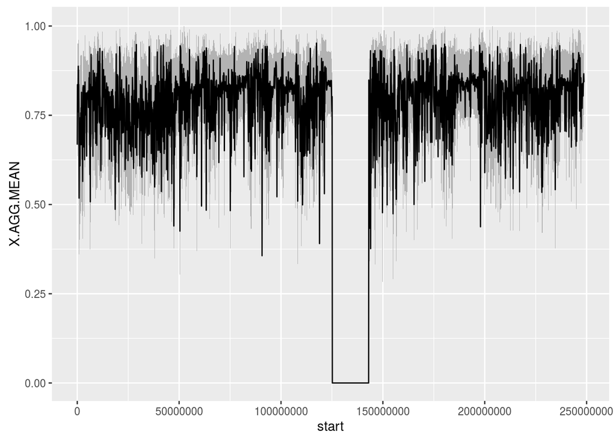

```r
library(ggplot2)
plot_data <- as.data.frame(regions)
plot_data[,grepl("X.", colnames(plot_data))] <- apply(plot_data[,grepl("X.", colnames(plot_data))], 2, as.numeric)
AGG.plot <- ggplot(plot_data, aes(start)) +
    geom_ribbon(aes(ymin = X.AGG.MEAN - (X.AGG.SD / 2), ymax = X.AGG.MEAN + (X.AGG.SD / 2)), fill = "grey70") +
    geom_line(aes(y = X.AGG.MEAN))
print(AGG.plot)
```

### Flanking regions

We use the `select_genes` command to generate a set of genes from the gene set gencode v19.

The `flank` command obtains flanking regions based on the existing regions. First, we generate regions that starts 2500bp before the regions and with the length of 2000bp. After, we generate the regions that starts 1500 bases pair after the regions end and have 500 base pairs. We consider the regions strand in both cases.

The `merge_queries` command merges the region sets defined by the query IDs. We merge the two flanking regions sets with the genes’ regions set.

We use the `get_regions` with the `query_id` that is returned by the `merge_queries`.

```r
# Select the RP11-34P13 gene locations from gencode v23
q_genes = deepblue.select_genes(genes_name=c("RNU6-1100P", "CICP7", "MRPL20", "ANKRD65", "HES2", "ACOT7", "HES3", "ICMT"), gene_set="gencode v19")

# Obtain the regions that starts 2500 bases pair before the regions start and have 2000 base pairs.
# The 4th argument inform that DeepBlue must consider the region strand (column STRAND) to calculate the new region
before_flank_id = deepblue.flank(query_id=q_genes, start=-2500, length=2000, use_strand=TRUE)

# Obtain the regions that starts 1500 bases pair after the regions end and have 500 base pairs.
# The 4th argument inform that DeepBlue must consider the region strand (column STRAND) to calculate the new region
after_flank_id = deepblue.flank(query_id=q_genes, start=1500, length=500, use_strand=TRUE)

# Merge both flanking regions set and genes set
flank_merge_id = deepblue.merge_queries(query_a_id =before_flank_id, query_b_id=after_flank_id)
all_merge_id = deepblue.merge_queries(query_a_id=q_genes, query_b_id=flank_merge_id)

# Request the regions
request_id = deepblue.get_regions(query_id=all_merge_id, output_format="CHROMOSOME,START,END,STRAND,@LENGTH")

regions = deepblue.download_request_data(request_id=request_id)
regions
```

```
## GRanges object with 26 ranges and 1 metadata column:
##        seqnames               ranges strand   |     @LENGTH
##           <Rle>            <IRanges>  <Rle>   | <character>
##    [1]     chr1     [155784, 156284]      -   |         500
##    [2]     chr1     [157784, 157887]      -   |         103
##    [3]     chr1     [160387, 162387]      -   |        2000
##    [4]     chr1     [327431, 327931]      -   |         500
##    [5]     chr1     [329431, 332236]      -   |        2805
##    ...      ...                  ...    ... ...         ...
##   [22]     chr1 [ 6470478,  6470978]      -   |         500
##   [23]     chr1 [ 6472478,  6484730]      -   |       12252
##   [24]     chr1 [ 6487230,  6489230]      -   |        2000
##   [25]    chr21 [38364443, 38366443]      +   |        2000
##   [26]    chr21 [38366943, 38367375]      +   |         432
##   -------
##   seqinfo: 2 sequences from an unspecified genome; no seqlengths
```

### Calculated columns

We use the `get_regions` command with the `query_id` value returned by the `select_experiments` and the desired file columns.

The command `aggregate` aggregates the `query_id` regions by their column named VALUE, using the `cpg_islands` regions as boundaries.

We select the `aggregated` regions that aggregated at least one region from the selected experiments (@AGG.COUNT > 0).

The aggregation values can be accessed through the @AGG meta-columns.

We use the `get_regions` with the `query_id` value returned by the `select_experiments` and the desired file columns. We use the @CALCULATED meta-column to transform the aggregate region @AGG.MEAN value to its log scale value.

```r
# Select the RP11-34P13 gene locations from gencode v23

# Selecting the data from 2 experiments: GC_T14_10.CPG_methylation_calls.bs_call.GRCh38.20150707.wig
# As we already know the experiments names, we keep all others fields empty.
# We are selecting all regions of chromosome 1
query_id = deepblue.select_experiments (experiment="GC_T14_10.CPG_methylation_calls.bs_call.GRCh38.20150707.wig", chromosome="chr1")

# Select the CpG Islands annotation from GRCh38
cpg_islands = deepblue.select_annotations(annotation="CpG Islands", genome="GRCh38", chromosome="chr1")

# Aggregate
overlapped = deepblue.aggregate (data_id=query_id, ranges_id=cpg_islands, column="VALUE")

# Select the aggregated regions that aggregated at least one region from the selected experiments (@AGG.COUNT > 0)
filtered = deepblue.filter_regions(query_id=overlapped, field="@AGG.COUNT", operation=">", value="0", type="number")

# We remove all regions where the aggregation mean is zero.
filtered_zeros = deepblue.filter_regions(query_id=filtered, field="@AGG.MEAN", operation="!=", value="0.0", type="number")

# Retrieve the experiments data (The @NAME meta-column is used to include the experiment name and @BIOSOURCE for experiment's biosource
request_id = deepblue.get_regions(query_id=filtered_zeros, output_format="CHROMOSOME,START,END,@CALCULATED(return math.log(value_of('@AGG.MEAN'))),@AGG.MEAN,@AGG.COUNT")

regions = deepblue.download_request_data(request_id=request_id)

# We have to perform a manual conversion because the package can't know the type for calculated columns
regions$`@CALCULATED(return math.log(value_of('@AGG.MEAN')))` =  as.numeric(regions$`@CALCULATED(return math.log(value_of('@AGG.MEAN')))`)

head(regions, 5)
```

```
## GRanges object with 5 ranges and 3 metadata columns:
##       seqnames           ranges strand |
##          <Rle>        <IRanges>  <Rle> |
##   [1]     chr1 [ 28735,  29737]      * |
##   [2]     chr1 [135124, 135563]      * |
##   [3]     chr1 [368792, 370063]      * |
##   [4]     chr1 [381172, 382185]      * |
##   [5]     chr1 [491107, 491546]      * |
##       @CALCULATED(return math.log(value_of('@AGG.MEAN')))   @AGG.MEAN
##                                                 <numeric> <character>
##   [1]                                           -7.600902      0.0005
##   [2]                                           -0.065819      0.9363
##   [3]                                            0.000000      1.0000
##   [4]                                           -0.043430      0.9575
##   [5]                                           -0.046044      0.9550
##        @AGG.COUNT
##       <character>
##   [1]          64
##   [2]          30
##   [3]           2
##   [4]          12
##   [5]          21
##   -------
##   seqinfo: 1 sequence from an unspecified genome; no seqlengths
```

Any numerical values returned by DeepBlue can also be conveniently displayed using, for example, the DataTrack feature of the GViz bioconductor package as shown here:

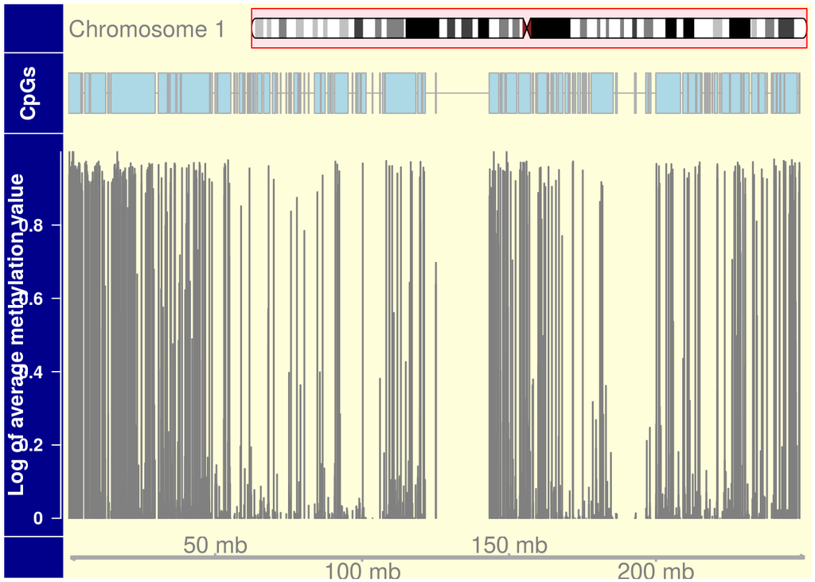

```r
library(Gviz)
atrack <- AnnotationTrack(regions, name = "CpGs", group = regions$`@BIOSOURCE`, genome="hg38")
gtrack <- GenomeAxisTrack()
itrack <- IdeogramTrack(genome = "hg38", chromosome = "chr1")
dtrack <- DataTrack(regions, data="@AGG.MEAN", name = "Log of average methylation value")
plotTracks(list(itrack, atrack, dtrack, gtrack), type="histogram", fontsize=18,
           background.panel = "#FFFEDB", background.title = "darkblue")
```

### Score matrix

The list `experiments` contains the names of the experiments fow which we want to build a score matrix.

We will build the score matrix using the column named VALUE.

We select the CpG islands, which will be used as aggregated regions boundaries.

The `score_matrix` command receives the dictionary with the experiments names and columns that will be used for aggregation, the regions’ boundaries, and the operation that will be performed (min, max, mean, var, sd, median, count).

The `score_matrix` command is asynchronous. It means that the user receives a `request_id` and should check the status of this request. The specific DeepBlue-R package command `download_request_data` wait for the processing finishes in the server, download the data, and convert to a GRanges object.

```r
experiments = c("GC_T14_10.CPG_methylation_calls.bs_call.GRCh38.20150707.wig", "C003N351.CPG_methylation_calls.bs_call.GRCh38.20150707.wig", "C005VG51.CPG_methylation_calls.bs_call.GRCh38.20150707.wig", "S002R551.CPG_methylation_calls.bs_call.GRCh38.20150707.wig", "NBC_NC11_41.CPG_methylation_calls.bs_call.GRCh38.20150707.wig", "bmPCs-V156.CPG_methylation_calls.bs_call.GRCh38.20150707.wig", "S00BS451.CPG_methylation_calls.bs_call.GRCh38.20150707.wig", "S00D1DA1.CPG_methylation_calls.bs_call.GRCh38.20150707.wig", "S00D39A1.CPG_methylation_calls.bs_call.GRCh38.20150707.wig")

experiments_columns = list()
for (experiment_name in experiments) {
    experiments_columns[[experiment_name]] = "VALUE"
}

cpgs = deepblue.select_annotations(annotation_name="Cpg Islands", chromosome="chr22", start=0, end=18000000, genome="hg19")

request_id = deepblue.score_matrix(experiments_columns=experiments_columns, aggregation_function="mean", aggregation_regions_id=cpgs)

score_matrix = deepblue.download_request_data(request_id=request_id)
head(score_matrix, 5)
```

```
##   CHROMOSOME    START      END
## 1      chr22 16122622 16122923
## 2      chr22 16155753 16158017
## 3      chr22 16192654 16193098
## 4      chr22 16200149 16200707
## 5      chr22 16217287 16217676
##   C003N351.CPG_methylation_calls.bs_call.GRCh38.20150707.wig
## 1                                                         NA
## 2                                                         NA
## 3                                                         NA
## 4                                                        0.6
## 5                                                        0.5
##   C005VG51.CPG_methylation_calls.bs_call.GRCh38.20150707.wig
## 1                                                         NA
## 2                                                         NA
```

[output cut: 45 more lines]

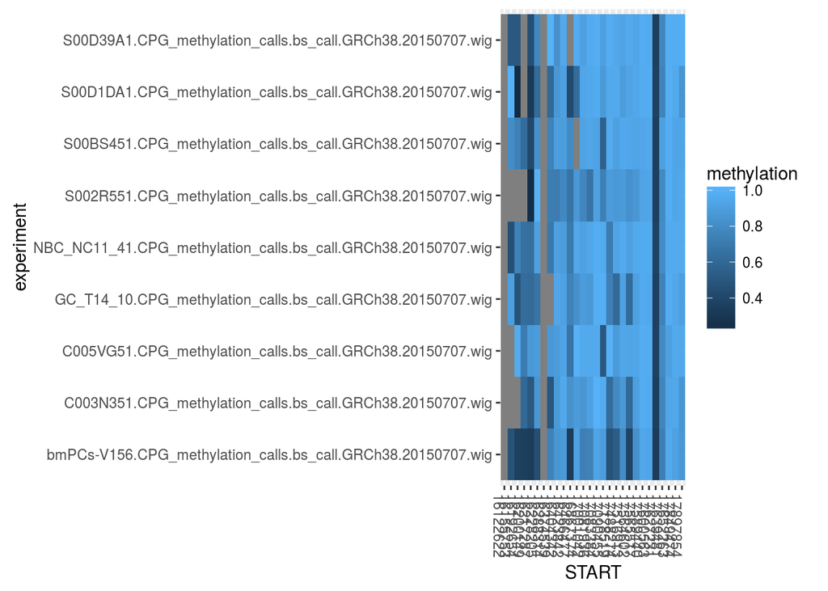